##### Estimate summary statistics

Here we use the `median_incident_symptomatic` function to estimate the median and 75th and 25th quantiles of the number of incident cases, hospitalizations, ICU admissions, ventilations, and deaths across simulations. Using the `median_counts_array` and `median_cumulative_array` functions we also estimate the number median and 75th and 25th quantiles of the cumulative counts of each condition.

Here it is possible to improve uncertainty estimation methods and use bootstrapping techniques across simulations to define a median, minimum and maximum value. However, as this document is for planning purposes this is not immediately necessary.

```r
median_incident_symptomatic<- function(data, R0val){
  median_incident_combined_R0val<- matrix(NA,n_days,ncol(data))

    for(i in 1:nrow(median_incident_combined_R0val)){
      median_incident_combined_R0val[i,]<-
        apply(data[which(data[,1]==i),],2,median)
    }
  upper_incident_combined_R0val<- matrix(NA,n_days,ncol(data))

    for(i in 1:nrow(upper_incident_combined_R0val)){
      upper_incident_combined_R0val[i,]<-
        apply(data[which(data[,1]==i),],2,quantile, probs=(0.75), na.rm=TRUE)
    }

  lower_incident_combined_R0val<- matrix(NA,n_days,ncol(data))

    for(i in 1:nrow(lower_incident_combined_R0val)){
      lower_incident_combined_R0val[i,]<-
        apply(data[which(data[,1]==i),],2,quantile, probs=(0.25), na.rm=TRUE)
    }


  return(list(median_incident_combined_R0val, upper_incident_combined_R0val,
              lower_incident_combined_R0val))
  }

incident_symptomatic_R017<- median_incident_symptomatic(combined_incident_R017,R017)
median_incident_symptomatic_R017<- incident_symptomatic_R017[[1]]
upper_incident_symptomatic_R017<- incident_symptomatic_R017[[2]]
lower_incident_symptomatic_R017<- incident_symptomatic_R017[[3]]


incident_symptomatic_R021<- median_incident_symptomatic(combined_incident_R021,R021)
median_incident_symptomatic_R021<- incident_symptomatic_R021[[1]]
upper_incident_symptomatic_R021<- incident_symptomatic_R021[[2]]
lower_incident_symptomatic_R021<- incident_symptomatic_R021[[3]]

incident_symptomatic_R025<- median_incident_symptomatic(combined_incident_R025,R025)
median_incident_symptomatic_R025<- incident_symptomatic_R025[[1]]
upper_incident_symptomatic_R025<- incident_symptomatic_R025[[2]]
lower_incident_symptomatic_R025<- incident_symptomatic_R025[[3]]

####################################################################

median_counts_array<- function(data, R0val){
  median_counts_array<- array(NA, dim=c(n_days,dim(data)[2], dim(data)[3]))

  for(i in 1:dim(median_counts_array)[3]){
    for(j in 1:dim(median_counts_array)[1]){
      median_counts_array[j,,i]<- apply(data[which(data[,1,1]==j),,i],2,median)
    }
  }

   upper_counts_array<- array(NA, dim=c(n_days,dim(data)[2], dim(data)[3]))

  for(i in 1:dim(upper_counts_array)[3]){
    for(j in 1:dim(upper_counts_array)[1]){
      upper_counts_array[j,,i]<- apply(data[which(data[,1,1]==j),,i],2,quantile, prob=0.75,na.rm=T)
    }
  }

    lower_counts_array<- array(NA, dim=c(n_days,dim(data)[2], dim(data)[3]))

  for(i in 1:dim(lower_counts_array)[3]){
    for(j in 1:dim(lower_counts_array)[1]){
      lower_counts_array[j,,i]<- apply(data[which(data[,1,1]==j),,i],2,quantile, prob=0.25,na.rm=T)
    }
  }
    return(list(median_counts_array, upper_counts_array,lower_counts_array))
}

summary_counts_array_R017<- median_counts_array(counts_array_R017,R017)
median_counts_array_R017<- summary_counts_array_R017[[1]]
upper_counts_array_R017<- summary_counts_array_R017[[2]]
lower_counts_array_R017<- summary_counts_array_R017[[3]]

summary_counts_array_R021<- median_counts_array(counts_array_R021,R021)
median_counts_array_R021<- summary_counts_array_R021[[1]]
upper_counts_array_R021<- summary_counts_array_R021[[2]]
lower_counts_array_R021<- summary_counts_array_R021[[3]]

summary_counts_array_R025<- median_counts_array(counts_array_R025,R025)
median_counts_array_R025<- summary_counts_array_R025[[1]]
upper_counts_array_R025<- summary_counts_array_R025[[2]]
lower_counts_array_R025<- summary_counts_array_R025[[3]]

########################################

median_cumulative_array<- function(data, R0val){
  median_cumulative_array<- array(NA, dim=c(n_days,dim(data)[2], dim(data)[3]))

  for(i in 1:dim(median_cumulative_array)[3]){
    for(j in 1:dim(median_cumulative_array)[1]){
      median_cumulative_array[j,,i]<- apply(data[which(data[,1,1]==j),,i],2,median,na.rm=T)
    }
  }

   upper_cumulative_array<- array(NA, dim=c(n_days,dim(data)[2], dim(data)[3]))

  for(i in 1:dim(upper_cumulative_array)[3]){
    for(j in 1:dim(upper_cumulative_array)[1]){
      upper_cumulative_array[j,,i]<- apply(data[which(data[,1,1]==j),,i],2,quantile, prob=0.75,na.rm=T)
    }
  }

    lower_cumulative_array<- array(NA, dim=c(n_days,dim(data)[2], dim(data)[3]))

  for(i in 1:dim(lower_cumulative_array)[3]){
    for(j in 1:dim(lower_cumulative_array)[1]){
      lower_cumulative_array[j,,i]<- apply(data[which(data[,1,1]==j),,i],2,quantile, prob=0.25,na.rm=T)
    }
  }
    return(list(median_cumulative_array, upper_cumulative_array,lower_cumulative_array))
}


summary_cumulative_array_R017<- median_cumulative_array(cumulative_array_R017,R017)
median_cumulative_array_R017<- summary_cumulative_array_R017[[1]]
upper_cumulative_array_R017<- summary_cumulative_array_R017[[2]]
lower_cumulative_array_R017<- summary_cumulative_array_R017[[3]]

summary_cumulative_array_R021<- median_cumulative_array(cumulative_array_R021,R021)
median_cumulative_array_R021<- summary_cumulative_array_R021[[1]]
upper_cumulative_array_R021<- summary_cumulative_array_R021[[2]]
lower_cumulative_array_R021<- summary_cumulative_array_R021[[3]]

summary_cumulative_array_R025<- median_cumulative_array(cumulative_array_R025,R025)
median_cumulative_array_R025<- summary_cumulative_array_R025[[1]]
upper_cumulative_array_R025<- summary_cumulative_array_R025[[2]]
lower_cumulative_array_R025<- summary_cumulative_array_R025[[3]]
```

#### Figures

We can now use our summary data files to display figures. In this section we provide code to output figures that have been commonly requested. We present them by the following sections:

1. When and how big are the peaks for infections, hospitalizations, and deaths?
2. What are the daily estimates of how many hospital beds, ICU beds, and ventilators will be in use?
3. What is the potential total impact?

##### Part I. When and how big are the peaks of infections, hospitalizations, and deaths?

**Figure 1**. The median number of incident cases across simulations by day for each transmission scenario. We present 15 randomly selected simulations for each transmission scenario to demonstrate the uncertainty. We define the function to make Figure 1 as `make_fig_1`.

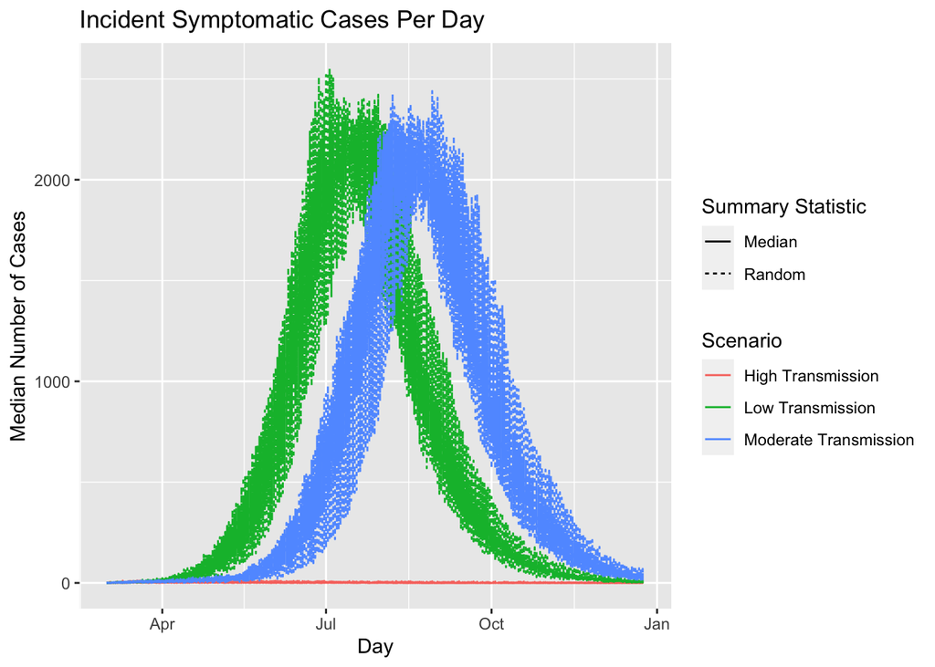

```r
make_fig_1<- function(complete_data_1,complete_data_2,complete_data_3,
                      median_data_1,median_data_2,median_data_3,
                      combined_data_1,combined_data_2,combined_data_3){
random_sample_R017<- which(complete_data_1$run_index%in%sample(rep(1:500),15,replace=F))
random_sample_R021<- which(complete_data_2$run_index%in%sample(rep(1:500), 15, replace=F))
random_sample_R025<- which(complete_data_3$run_index%in%sample(rep(1:500), 15, replace = F))


incident_symptomatic_wide<- as.data.frame(cbind(median_data_1[,1],
                            apply(median_data_1[,-1],1,sum),
                            apply(median_data_2[,-1],1,sum),
                            apply(median_data_3[,-1],1,sum)))

colnames(incident_symptomatic_wide)<- c("Day", "R_0=1.7,Median", "R_0=2.1,Median", "R_0=2.5,Median")

random_sims<- as.data.frame(cbind(combined_data_1[random_sample_R017,1],
                                apply(combined_data_1[random_sample_R017,-1],1,sum),
                                apply(combined_data_2[random_sample_R021,-1],1,sum),
                                apply(combined_data_3[random_sample_R021,-1],1,sum)))

colnames(random_sims)<- c("Day","R_0=1.7,Random", "R_0=2.1,Random", "R_0=2.5,Random")


incident_symptomatic_long<- incident_symptomatic_wide%>%
  gather(scenario, incident_symptomatic, "R_0=1.7,Median":"R_0=2.5,Median", factor_key = TRUE)

random_sims_long<- random_sims%>%
  gather(scenario, incident_symptomatic, "R_0=1.7,Random":"R_0=2.5,Random", factor_key=TRUE)


symptomatic_df<- as.data.frame(rbind(incident_symptomatic_long,random_sims_long))

symptomatic_df_sep<- symptomatic_df%>%
  separate(scenario, into=c("scenario", "summary_stat"), sep=",")%>%
  mutate(scenario=ifelse(scenario=="R_0=1.7", "Low Transmission",
                         ifelse(scenario=="R_0=2.1", "Moderate Transmission",
                                "High Transmission")))%>%
  mutate(Day=rep(seq(as.Date('2020/03/1'),by='day',length.out=n_days),48))



plt_incident_cases<- ggplot(symptomatic_df_sep)+
  geom_line(aes(y= incident_symptomatic, x=Day,color=scenario,linetype=summary_stat))+
  #geom_ribbon(aes(ymax=upper,ymin=lower,x=Day,fill=scenario), alpha=.5) +
  labs(title="Incident Symptomatic Cases Per Day",y="Median Number of Cases") +
  labs(color="Scenario",linetype="Summary Statistic")
return(list(plt_incident_cases,random_sample_R017,random_sample_R021,random_sample_R025))

}

f_1<- make_fig_1(complete_R017,complete_R021,complete_R025,
           median_incident_symptomatic_R017,median_incident_symptomatic_R021,
           median_incident_symptomatic_R025,
           combined_incident_R017,combined_incident_R021,combined_incident_R025)

f_1[[1]]
```

**Figure 2**. The median number of incident hospitalizations across simulations by day for each transmission scenario. We present 15 randomly selected simulations for each transmission scenario to demonstrate the uncertainty. We define the function to make Figure 2 as `make_fig_2`.

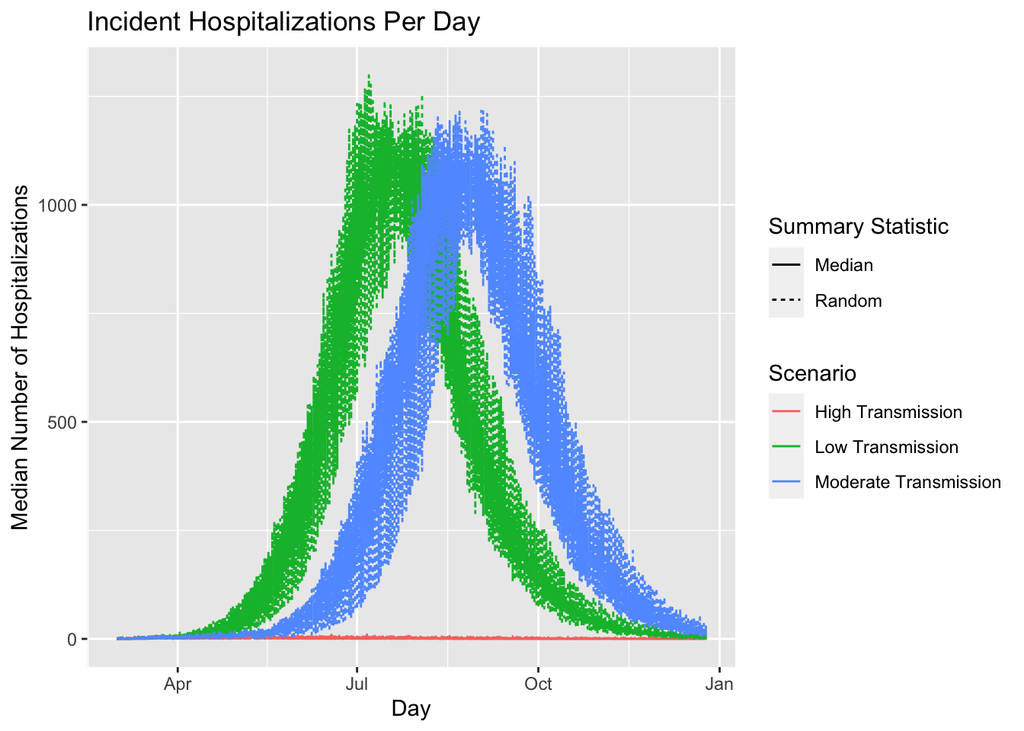

```r
make_fig_2<- function(random_sample_1,random_sample_2,random_sample_3,
                      counts_data_1,counts_data_2,counts_data_3,
                      median_counts_data_1,median_counts_data_2,median_counts_data_3){


incident_hosp_wide<- as.data.frame(cbind(median_counts_data_1[,1,1],
                            apply(median_counts_data_1[,-1,1],1,sum),
                            apply(median_counts_data_2[,-1,1],1,sum),
                            apply(median_counts_data_3[,-1,1],1,sum)))

colnames(incident_hosp_wide)<- c("Day", "R_0=1.7,Median", "R_0=2.1,Median", "R_0=2.5,Median")

random_sims<- as.data.frame(cbind(counts_data_1[random_sample_1,1,1],
                                apply(counts_data_1[random_sample_1,-1,1],1,sum),
                                apply(counts_data_2[random_sample_2,-1,1],1,sum),
                                apply(counts_data_3[random_sample_3,-1,1],1,sum)))

colnames(random_sims)<- c("Day","R_0=1.7,Random", "R_0=2.1,Random", "R_0=2.5,Random")


incident_hosp_long<- incident_hosp_wide%>%
  gather(scenario, incident_hosp, "R_0=1.7,Median":"R_0=2.5,Median", factor_key = TRUE)

random_sims_long<- random_sims%>%
  gather(scenario, incident_hosp, "R_0=1.7,Random":"R_0=2.5,Random", factor_key=TRUE)


hosp_df<- as.data.frame(rbind(incident_hosp_long,random_sims_long))

hosp_df_sep<- hosp_df%>%
  separate(scenario, into=c("scenario", "summary_stat"), sep=",")%>%
  mutate(scenario=ifelse(scenario=="R_0=1.7", "Low Transmission",
                         ifelse(scenario=="R_0=2.1", "Moderate Transmission",
                                "High Transmission")))%>%
  mutate(Day=rep(seq(as.Date('2020/03/1'),by='day',length.out=n_days),48))



plt_hosp_cases<- ggplot(hosp_df_sep)+
  geom_line(aes(y= incident_hosp, x=Day,color=scenario,linetype=summary_stat))+
  #geom_ribbon(aes(ymax=upper,ymin=lower,x=Day,fill=scenario), alpha=.5) +
  labs(title="Incident Hospitalizations Per Day",y="Median Number of Hospitalizations") +
  labs(color="Scenario",linetype="Summary Statistic")
return(plt_hosp_cases)
}

f_2<- make_fig_2(f_1[[2]],f_1[[3]],f_1[[4]],
                 counts_array_R017,counts_array_R021,counts_array_R025,
                 median_counts_array_R017,median_counts_array_R021,median_counts_array_R025)

f_2
```

**Figure 3**. The median number of incident deaths across simulations by day for each transmission scenario. We present 15 randomly selected simulations for each transmission scenario to demonstrate the uncertainty. We define the function to make Figure 3 as `make_fig_3`.

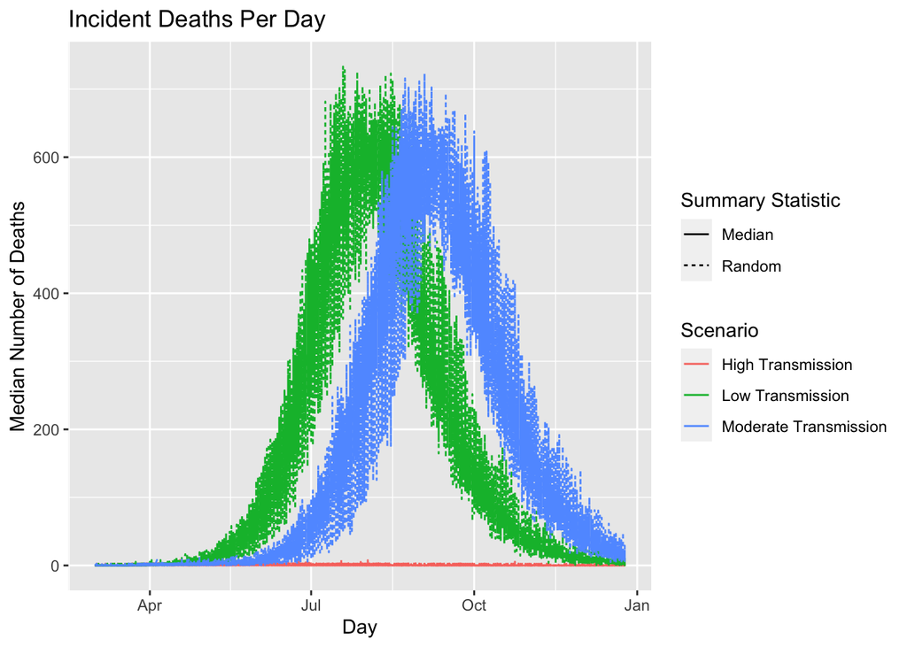

```r
make_fig_3<- function(random_sample_1,random_sample_2,random_sample_3,
                      counts_data_1,counts_data_2,counts_data_3,
                      median_counts_data_1,median_counts_data_2,median_counts_data_3){


incident_death_wide<- as.data.frame(cbind(median_counts_data_1[,1,5],
                            apply(median_counts_data_1[,-1,5],1,sum),
                            apply(median_counts_data_2[,-1,5],1,sum),
                            apply(median_counts_data_3[,-1,5],1,sum)))

colnames(incident_death_wide)<- c("Day", "R_0=1.7,Median", "R_0=2.1,Median", "R_0=2.5,Median")

random_sims<- as.data.frame(cbind(counts_data_1[random_sample_1,1,5],
                                apply(counts_data_1[random_sample_1,-1,5],1,sum),
                                apply(counts_data_2[random_sample_2,-1,5],1,sum),
                                apply(counts_data_3[random_sample_3,-1,5],1,sum)))

colnames(random_sims)<- c("Day","R_0=1.7,Random", "R_0=2.1,Random", "R_0=2.5,Random")


incident_death_long<- incident_death_wide%>%
  gather(scenario, incident_death, "R_0=1.7,Median":"R_0=2.5,Median", factor_key = TRUE)

random_sims_long<- random_sims%>%
  gather(scenario, incident_death, "R_0=1.7,Random":"R_0=2.5,Random", factor_key=TRUE)


death_df<- as.data.frame(rbind(incident_death_long,random_sims_long))

death_df_sep<- death_df%>%
  separate(scenario, into=c("scenario", "summary_stat"), sep=",")%>%
  mutate(scenario=ifelse(scenario=="R_0=1.7", "Low Transmission",
                         ifelse(scenario=="R_0=2.1", "Moderate Transmission",
                                "High Transmission")))%>%
  mutate(Day=rep(seq(as.Date('2020/03/1'),by='day',length.out=n_days),48))



plt_death_cases<- ggplot(death_df_sep)+
  geom_line(aes(y= incident_death, x=Day,color=scenario,linetype=summary_stat))+
  #geom_ribbon(aes(ymax=upper,ymin=lower,x=Day,fill=scenario), alpha=.5) +
  labs(title="Incident Deaths Per Day",y="Median Number of Deaths") +
  labs(color="Scenario",linetype="Summary Statistic")
return(plt_death_cases)
}

f_3<- make_fig_3(f_1[[2]],f_1[[3]],f_1[[4]],
                 counts_array_R017,counts_array_R021,counts_array_R025,
                 median_counts_array_R017,median_counts_array_R021,median_counts_array_R025)

f_3
```

##### Part II. What are the daily estimates of how many hospital beds, ICU beds, and ventilators will be in use?

**Figure 4**. Considering new daily infections, discharges, and time lags, we plot the median number of daily hospital beds, ICU beds, and ventilators in use for each transmission scenario. We present 15 randomly selected simulations for each transmission scenario to demonstrate the uncertainty. We define the function to make Figure 4 as `make_fig_4`.

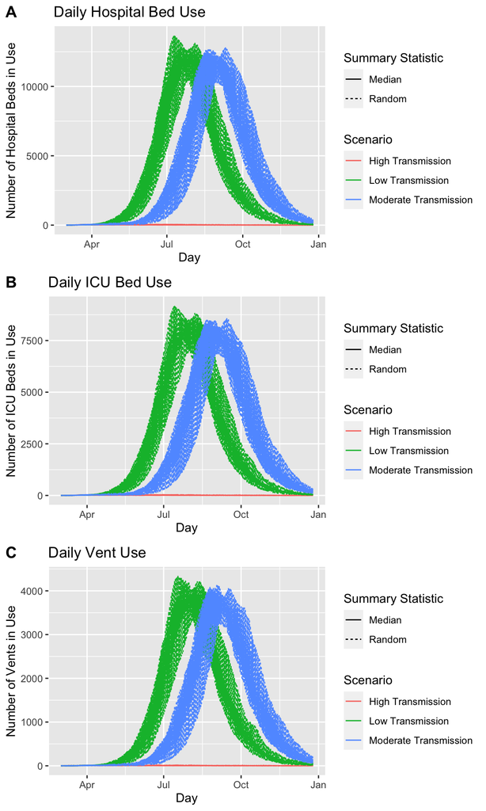

Figure 4.

```r
make_fig_4<- function(random_sample_1,random_sample_2,random_sample_3,
                      cumulative_median_1,cumulative_median_2,cumulative_median_3,
                      cumulative_data_1,cumulative_data_2,cumulative_data_3){

cumulative_hosp_wide<- as.data.frame(cbind(cumulative_median_1[,1,2],
                            apply(cumulative_median_1[,-1,2],1,sum),
                            apply(cumulative_median_2[,-1,2],1,sum),
                            apply(cumulative_median_3[,-1,2],1,sum)))

colnames(cumulative_hosp_wide)<- c("Day", "R_0=1.7,Median", "R_0=2.1,Median", "R_0=2.5,Median")

random_sims<- as.data.frame(cbind(cumulative_data_1[random_sample_1,1,2],
                                apply(cumulative_data_1[random_sample_1,-1,2],1,sum),
                                apply(cumulative_data_2[random_sample_2,-1,2],1,sum),
                                apply(cumulative_data_3[random_sample_3,-1,2],1,sum)))

colnames(random_sims)<- c("Day","R_0=1.7,Random", "R_0=2.1,Random", "R_0=2.5,Random")


cumulative_hosp_long<- cumulative_hosp_wide%>%
  gather(scenario, cumulative_hosp, "R_0=1.7,Median":"R_0=2.5,Median", factor_key = TRUE)

random_sims_long<- random_sims%>%
  gather(scenario, cumulative_hosp, "R_0=1.7,Random":"R_0=2.5,Random", factor_key=TRUE)


cumulative_hosp_df<- as.data.frame(rbind(cumulative_hosp_long,random_sims_long))

cumulative_hosp_df_sep<- cumulative_hosp_df%>%
  separate(scenario, into=c("scenario", "summary_stat"), sep=",")%>%
  mutate(scenario=ifelse(scenario=="R_0=1.7", "Low Transmission",
                         ifelse(scenario=="R_0=2.1", "Moderate Transmission",
                                "High Transmission")))%>%
  mutate(Day=rep(seq(as.Date('2020/03/1'),by='day',length.out=n_days),48))



plt_cumulative_hosp<- ggplot(cumulative_hosp_df_sep)+
  geom_line(aes(y= cumulative_hosp, x=Day,color=scenario,linetype=summary_stat))+
  #geom_ribbon(aes(ymax=upper,ymin=lower,x=Day,fill=scenario), alpha=.5) +
  labs(title="Daily Hospital Bed Use",y="Number of Hospital Beds in Use") +
  labs(color="Scenario",linetype="Summary Statistic")



###########################

cumulative_ICU_wide<- as.data.frame(cbind(cumulative_median_1[,1,3],
                            apply(cumulative_median_1[,-1,3],1,sum),
                            apply(cumulative_median_2[,-1,3],1,sum),
                            apply(cumulative_median_3[,-1,3],1,sum)))

colnames(cumulative_ICU_wide)<- c("Day", "R_0=1.7,Median", "R_0=2.1,Median", "R_0=2.5,Median")

random_sims<- as.data.frame(cbind(cumulative_data_1[random_sample_1,1,3],
                                apply(cumulative_data_1[random_sample_1,-1,3],1,sum),
                                apply(cumulative_data_2[random_sample_2,-1,3],1,sum),
                                apply(cumulative_data_3[random_sample_3,-1,3],1,sum)))

colnames(random_sims)<- c("Day","R_0=1.7,Random", "R_0=2.1,Random", "R_0=2.5,Random")


cumulative_ICU_long<- cumulative_ICU_wide%>%
  gather(scenario, cumulative_ICU, "R_0=1.7,Median":"R_0=2.5,Median", factor_key = TRUE)

random_sims_long<- random_sims%>%
  gather(scenario, cumulative_ICU, "R_0=1.7,Random":"R_0=2.5,Random", factor_key=TRUE)


cumulative_ICU_df<- as.data.frame(rbind(cumulative_ICU_long,random_sims_long))

cumulative_ICU_df_sep<- cumulative_ICU_df%>%
  separate(scenario, into=c("scenario", "summary_stat"), sep=",")%>%
  mutate(scenario=ifelse(scenario=="R_0=1.7", "Low Transmission",
                         ifelse(scenario=="R_0=2.1", "Moderate Transmission",
                                "High Transmission")))%>%
  mutate(Day=rep(seq(as.Date('2020/03/1'),by='day',length.out=n_days),48))



plt_cumulative_ICU<- ggplot(cumulative_ICU_df_sep)+
  geom_line(aes(y= cumulative_ICU, x=Day,color=scenario,linetype=summary_stat))+
  #geom_ribbon(aes(ymax=upper,ymin=lower,x=Day,fill=scenario), alpha=.5) +
  labs(title="Daily ICU Bed Use",y="Number of ICU Beds in Use") +
  labs(color="Scenario",linetype="Summary Statistic")

############################

cumulative_vent_wide<- as.data.frame(cbind(cumulative_median_1[,1,4],
                            apply(cumulative_median_1[,-1,4],1,sum),
                            apply(cumulative_median_2[,-1,4],1,sum),
                            apply(cumulative_median_3[,-1,4],1,sum)))

colnames(cumulative_vent_wide)<- c("Day", "R_0=1.7,Median", "R_0=2.1,Median", "R_0=2.5,Median")

random_sims<- as.data.frame(cbind(cumulative_data_1[random_sample_1,1,4],
                                apply(cumulative_data_1[random_sample_1,-1,4],1,sum),
                                apply(cumulative_data_2[random_sample_2,-1,4],1,sum),
                                apply(cumulative_data_3[random_sample_3,-1,4],1,sum)))

colnames(random_sims)<- c("Day","R_0=1.7,Random", "R_0=2.1,Random", "R_0=2.5,Random")


cumulative_vent_long<- cumulative_vent_wide%>%
  gather(scenario, cumulative_vent, "R_0=1.7,Median":"R_0=2.5,Median", factor_key = TRUE)

random_sims_long<- random_sims%>%
  gather(scenario, cumulative_vent, "R_0=1.7,Random":"R_0=2.5,Random", factor_key=TRUE)


cumulative_vent_df<- as.data.frame(rbind(cumulative_vent_long,random_sims_long))

cumulative_vent_df_sep<- cumulative_vent_df%>%
  separate(scenario, into=c("scenario", "summary_stat"), sep=",")%>%
  mutate(scenario=ifelse(scenario=="R_0=1.7", "Low Transmission",
                         ifelse(scenario=="R_0=2.1", "Moderate Transmission",
                                "High Transmission")))%>%
  mutate(Day=rep(seq(as.Date('2020/03/1'),by='day',length.out=n_days),48))



plt_cumulative_vent<- ggplot(cumulative_vent_df_sep)+
  geom_line(aes(y= cumulative_vent, x=Day,color=scenario,linetype=summary_stat))+
  #geom_ribbon(aes(ymax=upper,ymin=lower,x=Day,fill=scenario), alpha=.5) +
  labs(title="Daily Vent Use",y="Number of Vents in Use") +
  labs(color="Scenario",linetype="Summary Statistic")

return(list(plt_cumulative_hosp,plt_cumulative_ICU,plt_cumulative_vent))

}

f_4<- make_fig_4(f_1[[2]],f_1[[3]],f_1[[4]],
           median_cumulative_array_R017,median_cumulative_array_R021,median_cumulative_array_R025,
           cumulative_array_R017,cumulative_array_R021,cumulative_array_R025)

plt <- cowplot::plot_grid(f_4[[1]] , f_4[[2]], f_4[[3]], labels=c('A','B','C'), align = "h", nrow=3)
print(plt)
```

##### Part III. What is the potential total impact?

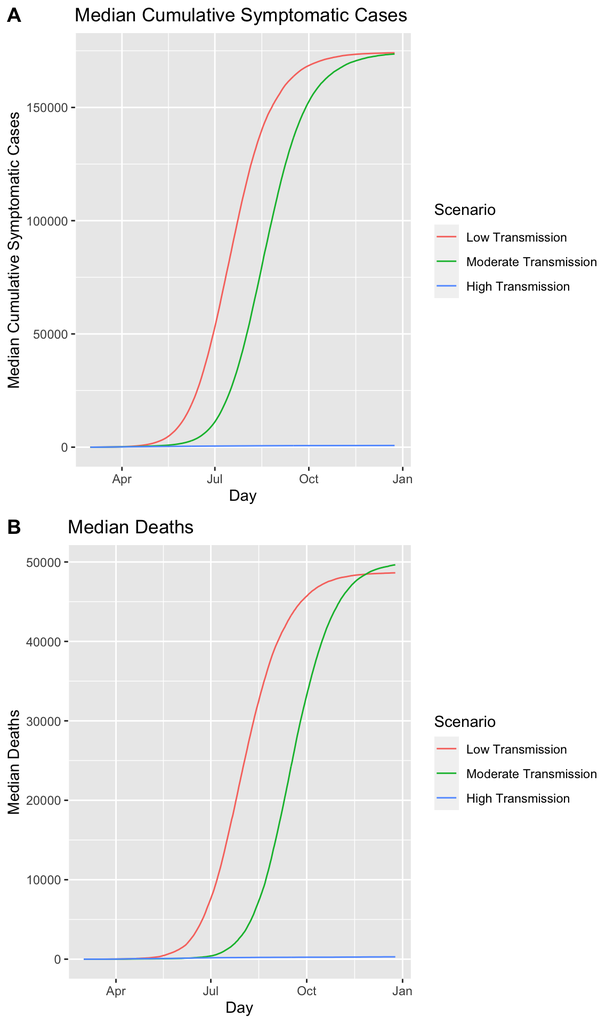

Figure 5.

```r
make_fig_5<- function(combined_data_1,combined_data_2,combined_data_3,
                      cumulative_data_1,cumulative_data_2,cumulative_data_3){
daily_incident_cases<- matrix(NA,nrow(combined_data_1),ncol=4)

daily_incident_cases[,1]<- combined_data_1[,1]
daily_incident_cases[,2]<- apply(combined_data_1[,-1],1,sum)
daily_incident_cases[,3]<- apply(combined_data_2[,-1],1,sum)
daily_incident_cases[,4]<- apply(combined_data_3[,-1],1,sum)

cumulative_cases_symptomatic<- matrix(NA, nrow(daily_incident_cases), ncol(daily_incident_cases))
cumulative_cases_symptomatic[,1]<- combined_data_1[,1]
cumulative_cases_symptomatic[which(cumulative_cases_symptomatic[,1]==1),]<-
  daily_incident_cases[which(daily_incident_cases[,1]==1),]
for(i in 2:n_days){
  for(j in 2: ncol(daily_incident_cases)){
    cumulative_cases_symptomatic[which(cumulative_cases_symptomatic[,1]==i),j]<-
      cumulative_cases_symptomatic[which(cumulative_cases_symptomatic[,1]==(i-1)),j]+
      daily_incident_cases[which(daily_incident_cases[,1]==i),j]
  }

}

median_cumulative_cases_symptomatic<- matrix(NA, n_days, ncol= 4)

median_cumulative_cases_symptomatic[,1]<- rep(1:n_days)
for(i in 1:nrow(median_cumulative_cases_symptomatic)){
  median_cumulative_cases_symptomatic[i,-1]<-
    apply(cumulative_cases_symptomatic[which(cumulative_cases_symptomatic[,1]==i),-1],2,median)
}

cumulative_cases_symptomatic<- as.data.frame(median_cumulative_cases_symptomatic)
colnames(cumulative_cases_symptomatic)<- c("Day", "Low Transmission",
                                          "Moderate Transmission", "High Transmission")

cumulative_cases_symptomatic_long<- cumulative_cases_symptomatic%>%
  gather(scenario, cumulative_cases, "Low Transmission": "High Transmission", factor_key = T)%>%
  mutate(Day= rep(seq(as.Date('2020/03/1'),by="day", length.out = n_days),3))



cumulative_symptomatic_cases_plt<- ggplot(cumulative_cases_symptomatic_long)+
  geom_line(aes(x=Day, y= cumulative_cases, color=scenario))+
  labs(y="Median Cumulative Symptomatic Cases", title= "Median Cumulative Symptomatic Cases",
       color="Scenario")

#cumulative deaths
cumulative_deaths<- as.data.frame(cbind(rep(1:nrow(cumulative_data_1[,,5])),
                    apply(cumulative_data_1[,-1,5],1,sum),
                    apply(cumulative_data_2[,-1,5],1,sum),
                    apply(cumulative_data_3[,-1,5],1,sum)))


median_cumulative_deaths<- matrix(NA, n_days, 4)
median_cumulative_deaths[,1]<- rep(1:n_days)
for(i in 1:nrow(median_cumulative_deaths)){

    median_cumulative_deaths[i,-1]<-
      apply(cumulative_deaths[which(cumulative_deaths[,1]==i),-1],2,median)

}

colnames(median_cumulative_deaths)<- c("Day", "Low Transmission", "Moderate Transmission",
                                       "High Transmission")

median_cumulative_deaths<- as.data.frame(median_cumulative_deaths)

median_cumulative_deaths_long<- median_cumulative_deaths%>%
  gather(scenario, cumulative_death, "Low Transmission": "High Transmission", factor_key = T)%>%
   mutate(Day= rep(seq(as.Date('2020/03/1'),by="day", length.out = n_days),3))


cumulative_deaths_plot<- ggplot(median_cumulative_deaths_long)+
  geom_line(aes(x=Day, y= cumulative_death, color=scenario))+
  labs(y= "Median Deaths", title="Median Deaths",color="Scenario")

return(list(cumulative_symptomatic_cases_plt,cumulative_deaths_plot))
}

f_5<- make_fig_5(combined_incident_R017,combined_incident_R021,combined_incident_R025,
                 cumulative_array_R017,cumulative_array_R021,cumulative_array_R025)

plt <- cowplot::plot_grid(f_5[[1]] , f_5[[2]], labels=c('A','B'), align = "h", nrow=2)
print(plt)
```